# Analysis of Prosper Loans

# Bivariate Analysis

This concludes the bivariate analysis. Some interesting findings were made and we now know much more about Prosper’s business and the peer-2-peer lending market as before.

### Talk about some of the relationships you observed in this part of the investigation. How did the feature(s) of interest vary with other features in the dataset?

We confirmed the expected relationship between borrowers’ APR and lenders’ yield. We confirmed that there is little possibility of getting a loan in Prosper without formal employment.

We saw the evolution of loan status by year to find that the financial crisis had a big impact on the business. Around 37% of loans given in 2007 were either charged-off or defaulted, at the time of data extraction.

### Did you observe any interesting relationships between the other features (not the main feature(s) of interest)?

We saw that Prosper has taken good care of not lending often to people whose monthly payments would represent more than 25% of their income, even if their monthly payments amount are in the highest ranges.

### What was the strongest relationship you found?

I confirmed expected strong relationships between APR and Lender Yield and between loan amount and monthly payments.

# Multivariate Plots Section

## Monthly payment/income ratio vs Loan Status and Home Ownership

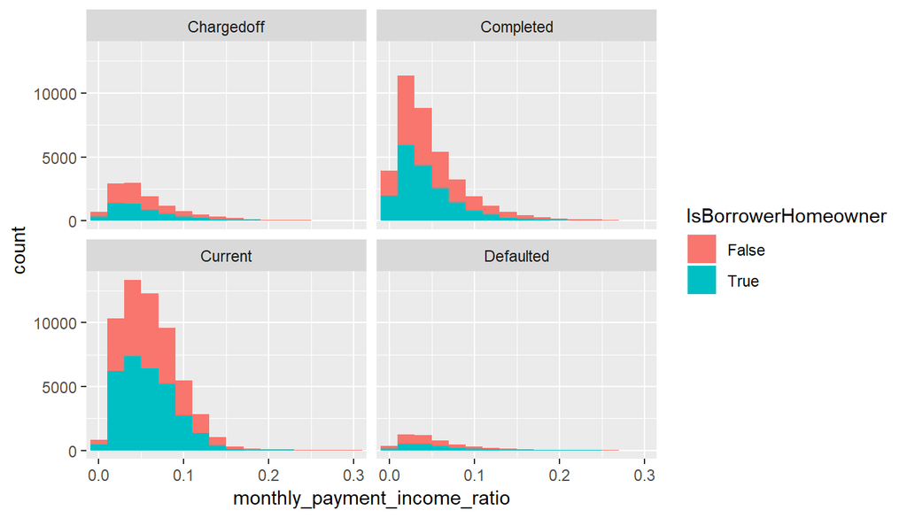

**Notes**: It is interesting to see that for non-homeowners, the monthly payment/income ratio stretches to the right indicating that they pay proportionally more for loans. The proportion of defaulted and charged-off loans remains rather evenly distributed.

## Borrower APR vs Loan Status and Prosper Listing rating

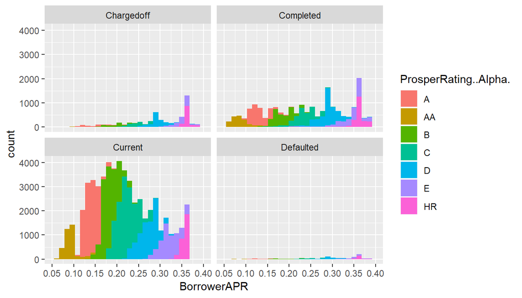

**Notes**: In this chart it is possible to see that across all listing status, the distribution of Borrower APR is higher for riskier loans. This is predictable and means that borrower pay more for their loans when having a less good credit profile.

## Monthly Loan Payments vs.monthly payment/income ratio and Loan Status

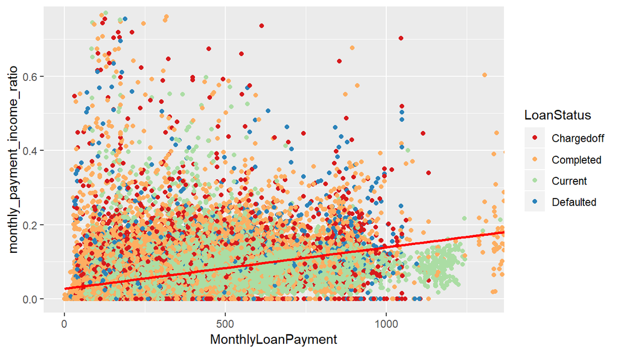

**Notes**: To the bivariate analysis of Monthly Loan Payment and monthly loan payment ratio, I now include the third variable *Loan Status*. No pattern emerges in this, our variables of interest.

## Loan amount by Prosper Score, Loan Status and Income Range

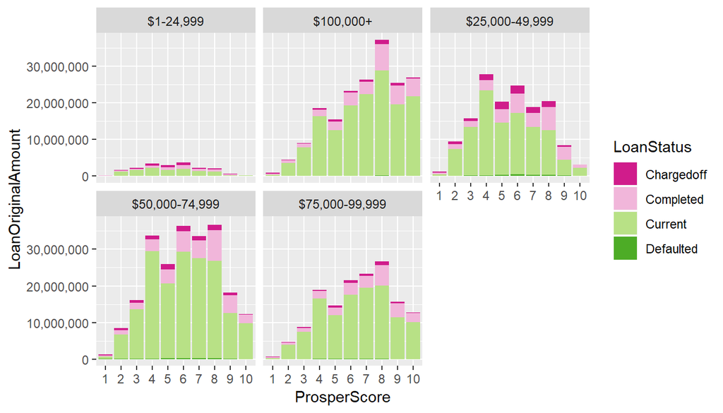

**Notes**: The highest revenue brackets have evidently better Prosper Scores and less charged-off loans.

## Default ratio by state and mean income

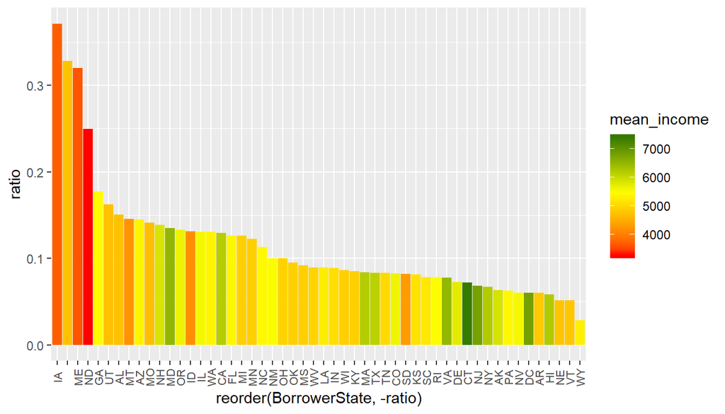

**Notes**: Very interestingly, we see that those states with the higher default ratio are also those whose borrowers declared to have the lowest mean income levels.

## Listings by Status and Home Ownership

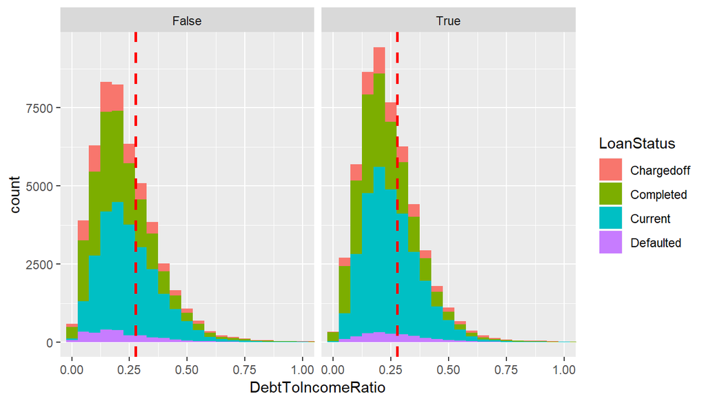

**Notes**: We find no meaningful difference in the distribution of the debt to income ratio when facetting by home ownership and coloring by Loan Status.

## Debt to income ratio by Prosper Score and Loan Status

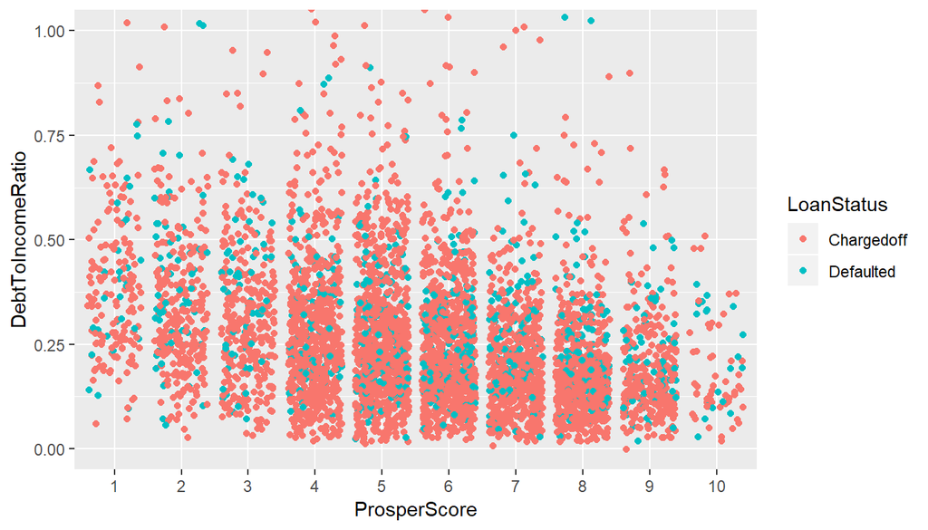

**Notes**: I expected to find a clearer relationship between the Debt to Income and the Prosper Score. A slight negative relationship is visible, with less debt to income ratio tending to have better (higher) Prosper scores.

# Multivariate Analysis

Talk about some of the relationships you observed in this part of the  
investigation. Were there features that strengthened each other in terms of  
looking at your feature(s) of interest?

### Were there any interesting or surprising interactions between features?

The relationship between the default ratio and the income level was clear when looking at this by the borrower’s state.

# Final Plots and Summary

### Plot One

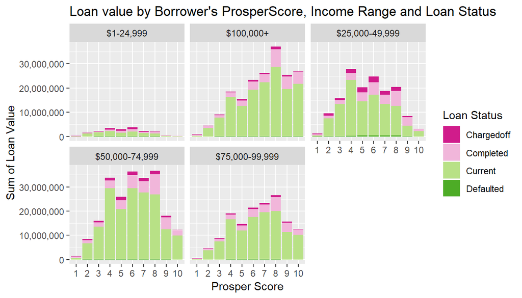

**Description**

This chart plots Prosper Loans by their Prosper Score, loan status and borrowers’ income brackets. The highest revenue brackets have evidently better Prosper Scores with their distributions tilted to the right. The two highest income brackets also have less charged-off loans than the next two brackets, and virtually no defaulted loans. This chart omits other statuses with relatively few cases for clarity.

### Plot Two

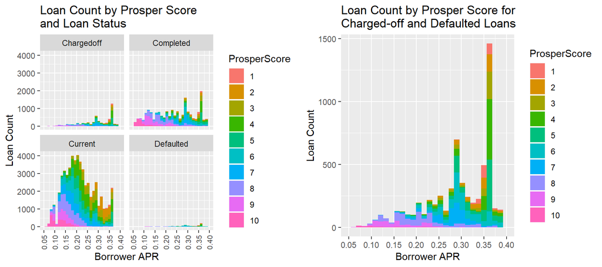

**Description**

This chart plots distributions of Prosper Listings, by Borrower APR, Prosper Score and Loan status. IN the left group, the largest amount of listings clearly have the status “current”. Borrower APR has a normal distribution for “current” listings, with an unexpected peak at around 35%. This raise appears for the other loan status as well. In the chart to the right, I aggregate the two “bad” status (Defaulted, and Charged-off), for better visualization. The peak we had already seen at APR = 35% is visible again, and we can see that most of the defaulted loans had a score of 4 and 5.

### Plot Three

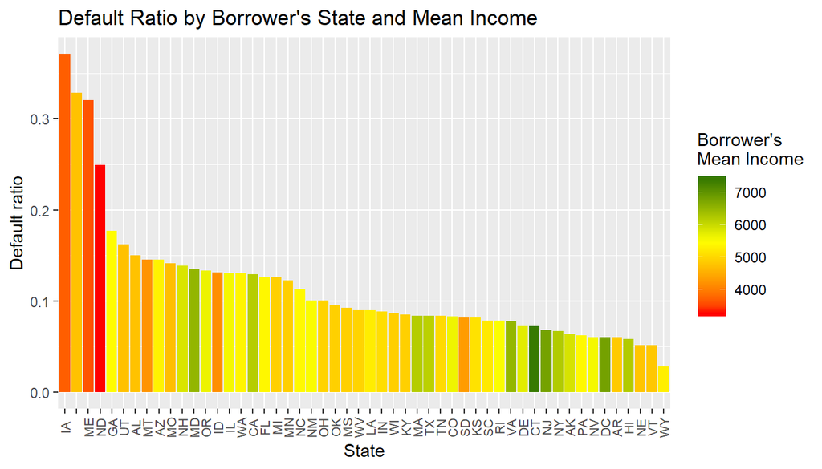

**Description**

This last chart, revisits the loan default ratio by borrower’s state, and adds the borrowers’ mean stated income. We had question why the states with more listings are not the ones with a higher default ratio. Here wee clearly see that the states with lower mean income tend to also have higher default ratios.

# Reflection

- I began this project not even knowing what peer-2-peer lending was. I spent quite some time readying about this innovation in financial services and its current development in the U.S. and abroad.
- I found interesting patterns in the data since the univariate exploratory data analysis, and ultimately found answers for every question I raised in the introduction.

**Some key findings include**:

- Prosper had a rapid growth after recovering from the 2008 financial crisis. By Q1 2014, it had a healthy portfolio with a large amount of live loans.
- By Q1 2014, the amount of listings with status “past due” was very low, which is a good indication of a healthy portfolio. Wit few “past due” loans, less defaulted and charged-off will come in the future.
- Prosper loans are simple, with almost all of them having a term or 3 or five years, and amounts of 3000, 5000 or 10000 US$. Most people borrow with Prosper for debt consolidation purposes.
- Based on the score the company gives to its listings, most of its portfolio has only moderate risk. There are more loans with the top 2 scores than in the bottom 2.
- The largest US states are the same with the most number of Prosper Loans. Those with higher default rates are those whose borrowers declared the lowest income range.
- Rather than a crowdsourcing platform, Prosper is really an intermediary for loans from one lender to one borrower.

**Further research**

- It would be interesting to compare the effectiveness of different credit ratings. In this dataset we have Prosper’s own score and a third party credit scoring.
- This data is five years old. After this time, it would be interesting to see whether the user base has changed and whether peer-2-peer lending has become more mainstream with larger borrowed amounts and with loans for further purposes like home or automobile purchases.

**Struggles**

- The large amount of variables required a long exploration time to understand. Being able to see potential connection between so many variables is an important skill to develop and that I was able to train on this project.
- Being my first exploratory analysis performed with R, it took me a lot of time to find solutions to many plotting functions. It was a great way to put into practice what I have learned in my Udacity training.